# Effects of Working Hours on economy and Individuals

# Exploration Overview

In this investigation we'll be looking to find the relationship between the working hours and other economic parameters like the GDP of the country and the unemployment rate as well as the average wages of the employeed. Is the common belief that if we work more hours we'll be more productive and gain more money?

# Dataset Overview

This is a collected dataset that contains information about different countries over the years concerning different financial aspects like the GDP - Average wages - Average Annual working hours - Unemployment rate, and the poverty rates were dropped due to the missing values and the inconsistency.

# Exploring The Data

This is a collected dataset containing information about average annual working hours - GDP - average wages - Unemployment across the countries and the years these data were collected and we want to know how working hours affect all of these parameters.

Now let's take a look at the distribution of the GDP.

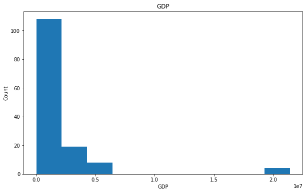

It's very clear that there's an oulier in the total GDP that needs more investigation to understand amd it can't be ignored.

So what's the relationship between the working hours and the GDP?

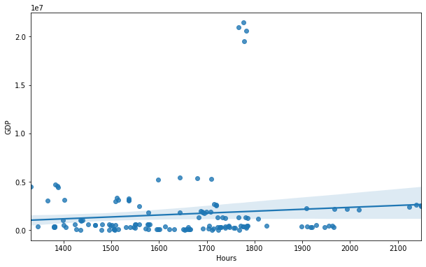

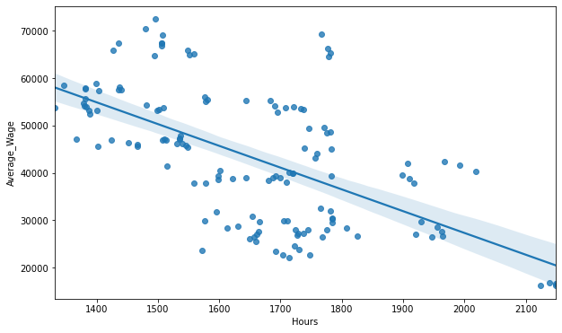

We can now see very clearly that average wage has a negative correlation with the yearly working hours with the highest averages lie between low to moderate number of hours.

After we've seen the distribution of the GDP we noticed an outlier so what's that outlier?

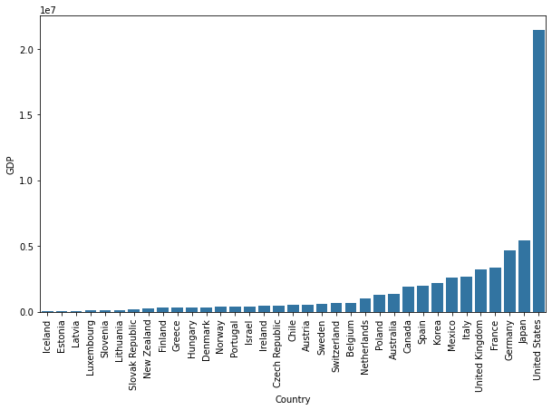

Here we can see it very clear that US is the outlier and we can't ignore it we actually need to investigate it further.

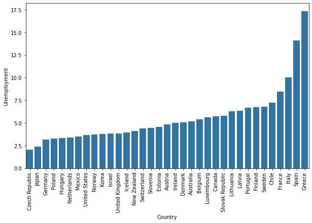

From that distribution we can notice 3 points: 1- the US which had the highest GDP by far, has a low unemployment rate but not the lowest at the same time. 2 - Greece has the highest unemployment rate with a very low GDP which makes sense. 3- Spain is the second most unemployment rate but has an okay GDP So let's investigate more

Now let's go back to the working hours, let's take a look at how it's distributed across the countries.

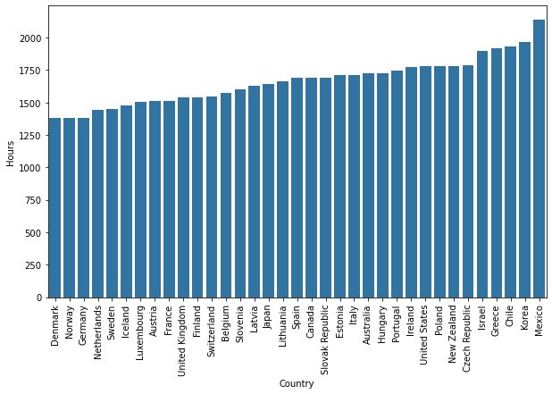

Here we can see some very interesting insights, cause Greece with the highest unemployment rate and a very low GDP is the 4th most country with yearly working hours as well as Mexico being the most country with working hours with an okay GDP and a low unemployment rate.

# CONCLUSIONS

2 - The highest average wages were associated with a moderate to low number of working hours which suggests that overload in work actually harms the worker as with higher working hours the wages are lower, not contributing much to the GDP nor being very productive.